# Supervised machine learning

Pablo Barbera

May 19, 2016

### Supervised machine learning

We’ll be working again with tweets about the 2014 EP elections in the UK. Now we will be using the `polite` variable, which indicates whether each tweet was hand-coded as being **polite** (a tweet that adheres to politeness standards, i.e. it is written in a well-mannered and non-offensive way) or **impolite** (an ill-mannered, disrespectful tweet that may contain offensive language).

The source of the dataset is a working paper co-authored with Yannis Theocharis, Zoltan Fazekas, and Sebastian Popa. The link is [here](http://pablobarbera.com/static/Theocharis_Barbera_Fazekas_Popa_APSA2015.pdf). Our goal was to understand to what extent candidates are not engaging voters on Twitter because they’re exposed to mostly impolite messages.

Let’s start by reading the dataset and creating a dummy variable indicating whether each tweet is impolite.

```r
library(quanteda)
tweets <- read.csv("../datasets/EP-elections-tweets.csv", stringsAsFactors=F)
tweets$impolite <- ifelse(tweets$polite=="polite", 0, 1)
```

We’ll do some cleaning as well – substituting handles with @, and removing all URLs. Why? We want to provent overfitting.

```r
tweets$text <- gsub('@[0-9_A-Za-z]+', '@', tweets$text)
tweets$text <- gsub('"(http.*) |(http.*)$|\n', "", tweets$text)
```

Create the dfm and trim it so that only tokens that appear in 2 or more tweets are included.

```r
twcorpus <- corpus(tweets$text)
twdfm <- dfm(twcorpus, ignoredFeatures=c(
  stopwords("english"), "t.co", "https", "rt", "amp", "http", "t.c", "can"))
```

```
## Creating a dfm from a corpus ...
##    ... lowercasing
##    ... tokenizing
##    ... indexing documents: 10,000 documents
##    ... indexing features: 10,592 feature types
##    ... removed 173 features, from 181 supplied (glob) feature types
##    ... created a 10000 x 10419 sparse dfm
##    ... complete.
## Elapsed time: 0.813 seconds.
```

```r
twdfm <- trim(twdfm, minDoc = 2)
```

```
## Removing features occurring in fewer than 2 documents: 3054
```

And split the dataset into training and test set. We’ll go with 80% training and 20% set. Note the use of a random seed to make sure our results are replicable.

```r
set.seed(123)
training <- sample(1:nrow(tweets), floor(.80 * nrow(tweets)))
test <- (1:nrow(tweets))[1:nrow(tweets) %in% training == FALSE]
```

Our first step is to train the classifier using cross-validation. There are many packages in R to run machine learning models. For regularized regression, glmnet is in my opinion the best. It’s much faster than caret or mlr (in my experience at least), and it has cross-validation already built-in, so we don’t need to code it from scratch.

```r
library(glmnet)
require(doMC)
```

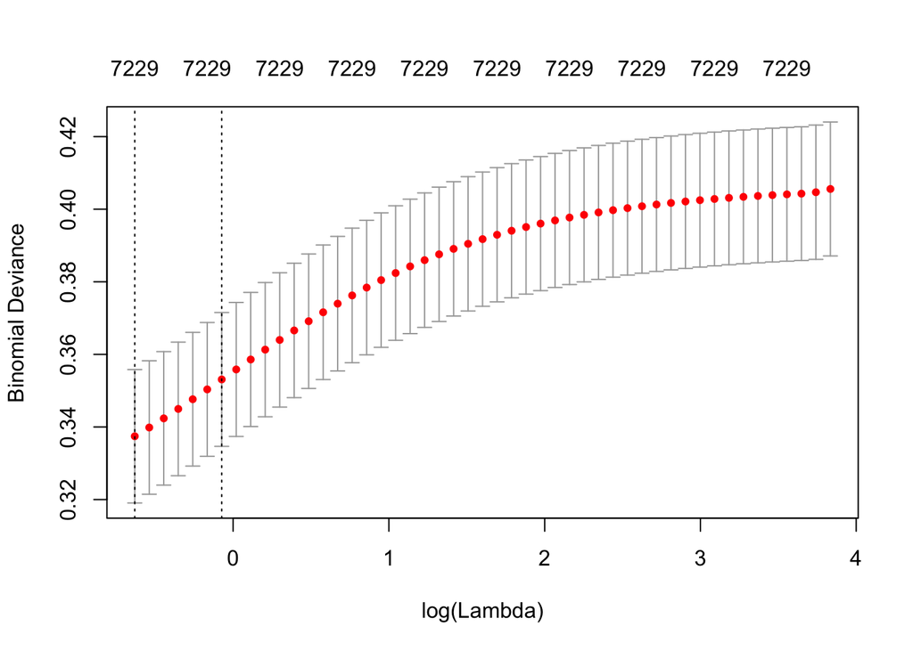

```r
registerDoMC(cores=3)
ridge <- cv.glmnet(twdfm[training,], tweets$impolite[training],
    family="binomial", alpha=0, nfolds=5, parallel=TRUE,
    type.measure="deviance")
plot(ridge)
```

We can now compute the performance metrics on the test set.

```r
## function to compute accuracy
accuracy <- function(ypred, y){
    tab <- table(ypred, y)
    return(sum(diag(tab))/sum(tab))
}
# function to compute precision
precision <- function(ypred, y){
    tab <- table(ypred, y)
    return((tab[2,2])/(tab[2,1]+tab[2,2]))
}
# function to compute recall
recall <- function(ypred, y){
    tab <- table(ypred, y)
    return(tab[2,2]/(tab[1,2]+tab[2,2]))
}
# computing predicted values
preds <- predict(ridge, twdfm[test,], type="response") > mean(tweets$impolite[test])
# confusion matrix
table(preds, tweets$impolite[test])
```

```
##
## preds      0    1
##   FALSE 1591   25
##   TRUE   311   73
```

```r
# performance metrics
accuracy(preds, tweets$impolite[test])
```

```
## [1] 0.832
```

```r
precision(preds, tweets$impolite[test])
```

```
## [1] 0.1901042
```

```r
recall(preds, tweets$impolite[test])
```

```
## [1] 0.744898
```

Something that is often very useful is to look at the actual estiamted coefficients and see which of these have the highest or lowest values:

```r
# from the different values of lambda, let's pick the best one
best.lambda <- which(ridge$lambda==ridge$lambda.min)
beta <- ridge$glmnet.fit$beta[,best.lambda]
head(beta)
```

```
##            @         ukip       thanks         will           eu
##  0.005087439  0.004143072 -0.058351540 -0.040403602 -0.043135491
##         vote
## -0.013744537
```

```r
## identifying predictive features
df <- data.frame(coef = as.numeric(beta),
                word = names(beta), stringsAsFactors=F)

df <- df[order(df$coef),]
head(df[,c("coef", "word")], n=30)
```

```
##            coef           word
## 5095 -0.2339869         haaaaa
## 7087 -0.1682714      corollary
## 4758 -0.1580270       sherlock
## 2078 -0.1531143       somebody
## 6474 -0.1497929      responses
## 5362 -0.1496664        villain
## 5361 -0.1496633        cockney
## 5360 -0.1496598           bald
## 3307 -0.1463065        tweeted
## 5451 -0.1459516           cole
## 4260 -0.1425340            giv
## 5812 -0.1411005 #leftiesinfear
## 5811 -0.1410973      unnoticed
## 1316 -0.1370590        kippers
```

[output cut: 16 more lines]

```r
paste(df$word[1:30], collapse=", ")
```

```
## [1] "haaaaa, corollary, sherlock, somebody, responses, villain, cockney, bald, tweeted, cole, giv, #leftiesinfear, unnoticed, kippers, makers, sheep, cry, password, whose, billy's, apace, yea, jokes, #ukitty, weed, ssc, soubry, immigratn, prattish, handsome"
```

```r
df <- df[order(df$coef, decreasing=TRUE),]
head(df[,c("coef", "word")], n=30)
```

```
##          coef          word
## 3386 1.542623         nigga
## 4372 1.528520        warner
## 6176 1.521048          sham
## 5788 1.517340         shush
## 6240 1.502013        rumour
## 3484 1.493465          scum
## 4192 1.471487         steps
## 4168 1.467738        ripped
## 5148 1.441802       fuckers
## 6324 1.409231          fits
## 6960 1.396527      #fuckoff
## 654  1.388486          cunt
## 5844 1.371915 maryhoneyball
## 4991 1.368601     #nigelpls
```

[output cut: 16 more lines]

```r
paste(df$word[1:30], collapse=", ")
```

```
## [1] "nigga, warner, sham, shush, rumour, scum, steps, ripped, fuckers, fits, #fuckoff, cunt, maryhoneyball, #nigelpls, wanker, sieg, mein, messy, carperbagger, man's, hitler, cunts, tit, slipping, mothers, dicks, cock, #mug, unlucky, pack"
```

### A special case: wordscores

Let’s check an example of wordscores. Here we have tweets from a random sample of 100 Members of the U.S. Congress, as well as their ideal points based on roll-call votes. Can we replicate the ideal points only using the text of their tweets?

```r
cong <- read.csv("../datasets/congress-tweets.csv", stringsAsFactors=F)
# creating the corpus and dfm objects
ccorpus <- corpus(cong$text)
docnames(ccorpus) <- cong$screen_name
cdfm <- dfm(ccorpus, ignoredFeatures=c(stopwords("english"), "t.co", "https", "rt", "amp", "http", "t.c", "can"))
```

```
## Creating a dfm from a corpus ...
##    ... lowercasing
##    ... tokenizing
##    ... indexing documents: 100 documents
##    ... indexing features: 182,596 feature types
##    ... removed 179 features, from 181 supplied (glob) feature types
##    ... created a 100 x 182417 sparse dfm
##    ... complete.
## Elapsed time: 8.197 seconds.
```

```r
cdfm <- trim(cdfm, minDoc = 2)
```

```
## Removing features occurring in fewer than 2 documents: 149659
```

```r
# running wordscores
ws <- textmodel(cdfm, cong$idealPoint, model="wordscores", smooth=.5)
ws
```

```
## Fitted wordscores model:
## Call:
##  textmodel_wordscores(data = x, scores = y, smooth = 0.5)
##
## Reference documents and reference scores:
##
##        Documents Ref scores
##      usreprodney       0.52
##      reprichmond      -0.78
##      rephanabusa      -0.98
##  repstevestivers       0.64
##   chrisvanhollen      -1.15
##  marshablackburn       1.21
##     repjohnlewis      -1.54
##      repstutzman       1.14
##      replipinski      -0.49
##   jacksonleetx18      -1.01
##        repveasey      -0.92
##   senatorisakson       0.90
##      repmurphyfl      -0.41
##      replankford       1.01
##  juliabrownley26      -0.77
##   repterrisewell      -0.74
##    repsusandavis      -1.14
##   senatorbaldwin      -1.29
##   reploisfrankel      -1.16
##    repmarktakano      -1.24
##  repjohnsarbanes      -1.49
##  vancemcallister       1.03
##     reptimmurphy       0.84
##    senatorwicker       0.89
##     repgwenmoore      -1.32
##  gracenapolitano      -1.35
##     senatorleahy      -1.01
##       senmikelee       1.48
##  repdonnaedwards      -1.70
##      repcummings      -1.40
##        sentoomey       1.07
##  replindasanchez      -1.63
##  repmickmulvaney       1.00
```

[output cut: 65 more lines]

```
##    senatorharkin      -0.80
##  repandyharrismd       1.10
##
## Word scores: showing first 30 scored features
##
##     today      will         w     house     great      bill    thanks
##    -0.105    -0.037    -0.308     0.063    -0.111    -0.074    -0.051
##       act       new       now    bit.ly       day        us      jobs
##    -0.219    -0.159    -0.181     0.188    -0.162    -0.264    -0.098
##      work    health      time   support     watch      live    senate
##    -0.367    -0.195    -0.228    -0.258     0.052     0.136     0.023
##      just      need     thank  congress      help    budget president
##     0.035    -0.320    -0.196    -0.210    -0.286     0.289     0.147
##      vote americans
##    -0.238    -0.245
```

```r
# let's look at the most discriminant words
sw <- sort(ws@Sw)
head(sw, n=20)
```

```
##              #wi    @repmarkpocan @replindasanchez              #p2
##       -1.3337740       -1.2675465       -1.2539131       -1.2069243
##  @usprogressives    @repgwenmoore     @repcummings  @repjohnconyers
##       -1.1726347       -1.1128055       -1.1098947       -1.1081180
##   @oversightdems    #raisethewage         #renewui               tb
##       -1.0950044       -1.0942480       -1.0782439       -1.0759828
##   #climatechange @repdonnaedwards     #gopshutdown   @repcartwright
##       -1.0461445       -1.0432564       -1.0423120       -1.0242637
##    @repjohnlewis   @senatorcardin    #actonclimate   @waysmeanscmte
##       -1.0240058       -1.0074236       -0.9947273       -0.9946359
```

```r
tail(sw, n=20)
```

```
## @replarrybucshon           #pjnet   @gopconference       #obamacare
##        0.6728316        0.6777415        0.6852008        0.6853861
##            is.gd            ow.ly     @edworkforce    @gopoversight
##        0.6857408        0.6931761        0.7034164        0.7064149
##        obamacare            #utah             #ar2      @toddrokita
##        0.7127336        0.7399828        0.7443255        0.7686107
##   #cutcapbalance        #sctweets        @repdavid            #tcot
##        0.7698602        0.7799295        0.8263009        0.8356432
##      @senmikelee           #4jobs           #utsen           #utpol
##        0.8589999        0.8775083        0.9440451        1.0903175
```

Now let’s split the data into training and test set and see what we can learn…

```r
set.seed(123)
test <- sample(1:nrow(cong), floor(.20 * nrow(cong)))
# extracting ideal points and replacing them with missing values
refpoints <- cong$idealPoint
refpoints[test] <- NA
# running wordscores
ws <- textmodel(cdfm, refpoints, model="wordscores", smooth=.5)
# predicted values (this will take a while...)
preds <- predict(ws, rescaling="lbg")
```

```
## 32758 of 32758 features (100%) can be scored
```

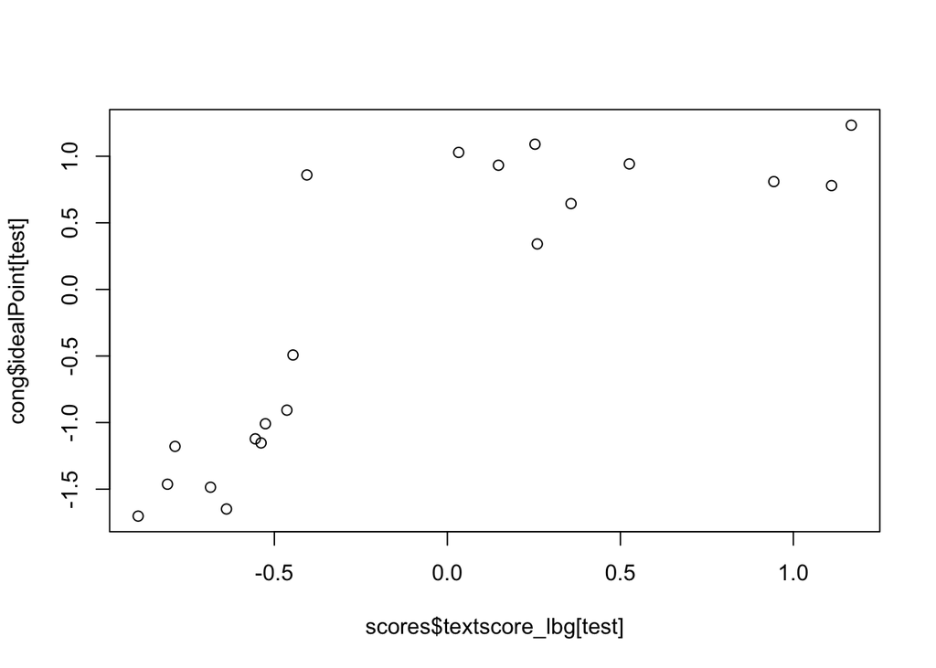

```r
scores <- preds@textscores
# and let's compare
plot(scores$textscore_lbg[test], cong$idealPoint[test])
```

```r
cor(scores$textscore_lbg[test], cong$idealPoint[test])
```

```
## [1] 0.8445735
```